# Homework 09

The kernel-tuning question moved here from Homework 08. A solution for Question 1 will be available after Monday, October 26, 2026. No solution will be provided for Question 2.

## Question 1: Choosing an SVM kernel

Use `saheart.csv` from the combined ZIP. As in Homework 7, predict `chd` using the same nine predictors, coding `famhist` as 1 for `Absent` and 2 for `Present`.

Compare SVMs with a linear kernel, polynomial kernels of degrees 2 (quadratic), 3, and 4, and a radial basis kernel. Choose **no more than 20 candidate settings in total** across these kernels. Vary the cost $C$ for each kernel and the radial scale $\gamma$ for the radial kernel. State any other kernel settings you hold fixed.

Divide the observations into five folds yourself and use the same folds for all candidates. Standardize predictors using only the fitting observations in each fold. Report the candidate settings and their mean cross-validation misclassification rates. Which kernel and settings do you prefer? Give a brief justification.

```r
library(e1071)

d <- read.csv("/Users/tangshiyu/Desktop/stat432-fall2026/homework/week-09/data/saheart.csv")
d$famhist <- ifelse(d$famhist == "Absent", 1, 2)
d$chd <- factor(d$chd)

vars <- c("sbp", "tobacco", "ldl", "adiposity", "famhist",
          "typea", "obesity", "alcohol", "age")
d <- d[, c("chd", vars)]

set.seed(432)
fold <- sample(rep(1:5, length.out = nrow(d)))

grid <- expand.grid(
  kernel = c("linear", "polynomial"),
  degree = 2:4,
  cost = c(0.1, 1, 10, 100),
  stringsAsFactors = FALSE
)
grid <- grid[grid$kernel == "polynomial" | grid$degree == 2, ]
grid$gamma <- 1/9

grid <- rbind(
  grid,
  data.frame(
    kernel = "radial", degree = 2,
    cost = rep(c(1, 10), each = 2),
    gamma = rep(c(0.01, 0.1), 2)
  )
)

grid$error <- NA_real_

for (i in seq_len(nrow(grid))) {
  error <- numeric(5)

  for (k in 1:5) {
    fit <- svm(
      chd ~ ., data = d[fold != k, ],
      kernel = grid$kernel[i],
      degree = grid$degree[i],
      cost = grid$cost[i],
      gamma = grid$gamma[i],
      coef0 = 1,
      scale = TRUE
    )

    pred <- predict(fit, d[fold == k, ])
    error[k] <- mean(pred != d$chd[fold == k])
  }

  grid$error[i] <- mean(error)
}

grid[order(grid$error), ]
```

```
       kernel degree  cost     gamma     error
11     radial      2   1.0 0.0100000 0.2618513
3      radial      2  10.0 0.0100000 0.2684198
2  polynomial      2   0.1 0.1111111 0.2705937
4  polynomial      3   0.1 0.1111111 0.2748948
21     radial      2   1.0 0.1000000 0.2770687
1      linear      2   0.1 0.1111111 0.2791491
8  polynomial      2   1.0 0.1111111 0.2792660
7      linear      2   1.0 0.1111111 0.2813230
13     linear      2  10.0 0.1111111 0.2813230
19     linear      2 100.0 0.1111111 0.2813230
6  polynomial      4   0.1 0.1111111 0.2813698
14 polynomial      2  10.0 0.1111111 0.2944367
20 polynomial      2 100.0 0.1111111 0.3009584
16 polynomial      3  10.0 0.1111111 0.3159888
10 polynomial      3   1.0 0.1111111 0.3182796
41     radial      2  10.0 0.1000000 0.3398551
12 polynomial      4   1.0 0.1111111 0.3398784
18 polynomial      4  10.0 0.1111111 0.3593502
22 polynomial      3 100.0 0.1111111 0.3657083
24 polynomial      4 100.0 0.1111111 0.3895278
```

I compared 20 candidate settings using the same five folds, standardizing predictors using only the training observations within each fold. For polynomial kernels, I fixed gamma at 1/9 and coef0 at 1.

I prefer the radial kernel with C = 1 and gamma = 0.01 because it achieved the lowest mean cross-validation misclassification rate, 0.2619 (26.19%), among the settings considered. Its advantage over the other leading candidates was small.

## Question 2: Write and use a short SVM analysis skill

In Homework 8, you reviewed another student’s skill. Review the comments and suggestions you received on your own Homework 7 skill. Use what you learned from both sides of the peer review to write a new, shorter skill for SVM model fitting.

**Write the skill by hand.** Create a `SKILL.md` with a short name and description in YAML frontmatter. Write the entire file yourself, without asking AI to draft or edit it. The instruction body after the closing `---` of the frontmatter must be **no more than 50 lines**, including blank lines. Keep the skill independent of any particular dataset, variable names, or observed results, and load it only when you explicitly invoke it.

Your skill should direct the agent to:

1. judge whether the data are suitable for an SVM analysis;
2. choose which kernels to consider and explain why;
3. identify tuning parameters and a method for tuning them;
4. choose an evaluation method that supports selecting a final model;
5. require a compact figure and table that justify the choices;
6. interpret the fit and report the key numerical results; and
7. prioritize the evidence needed to justify the final model in **no more than one printed page at 11-point font**.

**Apply the skill.** Explicitly invoke your skill to analyze `saheart.csv`, using the same response, nine predictors, and `famhist` coding as in Question 1. Provide these data details when invoking the skill, not in the skill itself. Let the skill guide the analysis, then check the resulting report and calculations.

**Submit the results.** Include the one-page, 11-point analysis report in your Homework 09 submission and append the complete contents of your `SKILL.md` afterward. The appended skill is outside the one-page limit.

### Invoking the skill

I wrote the skill in `SKILL.md` (appended below) and explicitly invoked it with only these data details: analyze `data/saheart.csv`, predicting `chd` from `sbp`, `tobacco`, `ldl`, `adiposity`, `famhist`, `typea`, `obesity`, `alcohol`, and `age`, with `famhist` coded 1 for `Absent` and 2 for `Present`. The skill directed the analysis and report below. The analysis code appears after the report and the skill.

### SVM analysis of coronary heart disease (skill: `svm-analysis`)

**Data and suitability.** n = 462 (302 without, 160 with CHD; positive class chd = 1), nine numeric predictors (`famhist` coded 1/2), no missing values or duplicate rows. A stratified 25% test set (n = 116) was split off first and left untouched; all later steps used the development set (n = 346). Standardization was fitted within each training fold. CV also compared $\log(1+x)$ versions of right-skewed predictors, chosen in each training fold as those with skewness > 1 and applied unchanged to its validation fold: tobacco and alcohol in all 50 folds, sbp in 48, ldl in 41, obesity in 31.

**Kernels and tuning.** Linear is the baseline for nine predictors. Quadratic (fixed $\gamma = 1/9$, coef0 = 1) adds pairwise interactions, and radial allows smooth nonlinearity. Cubic and quartic kernels were omitted as unstable at this n. Grids: $C \in \{0.01, 0.1, 1, 10\}$ (linear), $\{0.01, 0.1, 1\}$ (quadratic), and $\{0.1, 1, 10\} \times \gamma \in \{0.01, 0.03, 0.1\}$ (radial), each with raw or log predictors (32 candidates). The primary metric, misclassification rate (equal error costs), was estimated by 10 × 5-fold stratified CV (seed 432), with folds shared by all candidates.

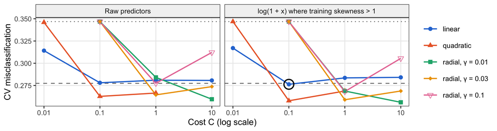

Mean 10×5-fold CV error. Dashed: best + 1 approx. SE; dotted: no-CHD rate; ringed: selected.

Leading candidates (development CV tuning scores, not final estimates); wins and rank IQR over 10 repetitions.

| Rank | Predictors | Kernel | C | γ | CV error (approx. SE) | Wins / 10 | Rank IQR |
| --- | --- | --- | --- | --- | --- | --- | --- |
| 1 | log(1+x) | radial | 10.0 | 0.010 | 0.256 (0.021) | 4 | 1-5 |
| 2 | log(1+x) | quadratic | 0.1 | 0.111 | 0.258 (0.018) | 4 | 1-4 |
| 3 | log(1+x) | radial | 1.0 | 0.030 | 0.259 (0.018) | 0 | 2-5 |
| 4 | raw | radial | 10.0 | 0.010 | 0.260 (0.020) | 1 | 3-5 |
| 13 | log(1+x) | **linear (selected)** | 0.1 | – | 0.276 (0.024) | 0 | 10-16 |

**Selection.** The best mean CV error was 0.256 (log, radial, C = 10, γ = 0.01; C at the grid’s upper boundary). However, 13 candidates lie within one SE (0.021), and the per-repetition winner varied (radial 5/10, quadratic 5/10, linear 0/10). These SEs, and the one-SE rule built on them, are approximate because overlapping training sets make fold errors dependent. The rule chose the simplest qualifying model, **linear kernel, log predictors, C = 0.1** (CV error 0.276). Its raw counterpart (0.278) narrowly missed the cutoff; the two are effectively tied.

**Final performance.** Refit on the development set (log predictors chosen there: sbp, tobacco, ldl, obesity, alcohol), the model’s test misclassification rate was **0.293** (95% Wilson CI 0.218–0.382, n = 116), versus 0.345 for always predicting no CHD. Sensitivity was 0.675 (27/40), and specificity was 0.724 (55/76). In development CV (0.486, 0.850), moving the decision-value threshold from 0 to −0.5 gave 0.685 and 0.707 but raised error to 0.301, so 0 was kept (no probability calibration).

**Interpretation and limitations.** The largest standardized weights toward CHD were famhist (0.45), age (0.42), ldl (0.33), tobacco (0.30). These are predictive associations, not causal effects. The test CI is wide. Given near-tied candidates and obesity’s borderline skewness (1.00), another seed could pick a different model with similar accuracy.

### Appendix: complete `SKILL.md`

```
---
name: svm-analysis
description: Fit, compare, and interpret SVM models when explicitly invoked.
---
Use this skill only when the user explicitly invokes it.

1. Confirm the response, predictors, coding, and prediction objective.
   Check sample size, missingness, class balance, duplicates, and predictor types.
   Judge SVM suitability, scaling needs, and limits on interpretation.
   SVMs do not require within-class normality; inspect skewness and outliers.
   Evaluate justified transformations by CV rather than assuming improvement.

2. Exclude identifiers and leakage variables; respect requested categorical coding.
   Fit imputation, transformations, and scaling within training folds only.
   Apply the fitted preprocessing unchanged to validation or test observations.

3. Consider linear and radial kernels; consider polynomial kernels when justified.
   Explain kernel choices using dimensionality and plausible nonlinearity.
   Respect the user's required kernels and candidate-setting limit.

4. Tune cost C for each kernel, radial gamma, and relevant polynomial settings.
   State search ranges and all fixed parameters, including gamma and coef0.
   Use a compact, reproducible grid; document optima at search boundaries.

5. Record the seed and use identical folds across candidates.
   Use stratified folds when feasible and justify the primary evaluation metric.
   Assess selection stability with repeated CV within development data.
   Summarize ranking variability or selection frequency across repetitions.
   Use nested CV or an untouched test set for final performance estimation.
   Distinguish tuning scores from final estimates; prevent evaluation leakage.

6. Select by the primary metric and explain any preference for a simpler model.
   Avoid treating small CV differences as decisive evidence.
   Refit the selected pipeline on development data after honest evaluation.

7. Include one compact labeled figure comparing tuning or validation performance.
   Include a small table of leading models, parameters, and validation scores.
   Clearly identify the selected model and the evaluation used for each score.

8. Report sample size, class counts, selected parameters, error, and uncertainty.
   For classification, report sensitivity, specificity, and the positive class.
   Examine decision-threshold tradeoffs using training CV only.
   Retain the primary selection metric and keep final evaluation data untouched.
   Use decision values unless probability calibration is justified.
   Interpret predictive results without causal claims or misleading coefficients.

9. Limit the report, including its figure and table, to one page at 11-point font.
   Prioritize evidence supporting the final model and acknowledge limitations.
   Verify calculations, reproducibility, labels, and rendered page count.
   Place code and the complete skill appendix outside the one-page report.
```

### Appendix: Question 2 analysis code

```r
library(e1071)
library(ggplot2)

sa <- read.csv("data/saheart.csv")
stopifnot(!anyNA(sa), !anyDuplicated(sa), all(sa$chd %in% 0:1))
sa$famhist <- ifelse(sa$famhist == "Absent", 1, 2)
vars <- c("sbp", "tobacco", "ldl", "adiposity", "famhist",
          "typea", "obesity", "alcohol", "age")
X <- as.matrix(sa[, vars])
y <- factor(sa$chd, levels = c(0, 1))          # positive class: chd = 1

strat_folds <- function(y, k) {
  f <- integer(length(y))
  for (l in levels(y)) {
    i <- which(y == l)
    f[i] <- sample(rep(1:k, length.out = length(i)))
  }
  f
}

set.seed(432)
test <- strat_folds(y, 4) == 1                  # untouched stratified 25% test set
Xd <- X[!test, ]; yd <- y[!test]
Xt <- X[test, ];  yt <- y[test]

# Candidate transformation, learned from the fitting observations only:
# log(1 + x) for continuous predictors whose skewness exceeds 1 in those data.
# The selected set is stored with the fit and applied unchanged to new data.
skew <- function(x) mean((x - mean(x))^3) / sd(x)^3
cont <- setdiff(vars, "famhist")
pick_skewed <- function(X) {
  s <- apply(X[, cont], 2, skew)
  names(s)[s > 1]
}
prep <- function(X, logv) {
  if (length(logv)) X[, logv] <- log1p(X[, logv])
  X
}
# 16 settings x 2 predictor versions = 32 candidates.
# Polynomial: degree 2, gamma = 1/9, coef0 = 1 (fixed).
cand <- rbind(
  data.frame(kernel = "linear", cost = c(0.01, 0.1, 1, 10), gamma = NA),
  data.frame(kernel = "polynomial", cost = c(0.01, 0.1, 1), gamma = 1/9),
  expand.grid(kernel = "radial", cost = c(0.1, 1, 10),
              gamma = c(0.01, 0.03, 0.1), stringsAsFactors = FALSE)
)
cand <- merge(data.frame(tr = c("raw", "log")), cand)
cand$id <- seq_len(nrow(cand))

# The log selection and scale = TRUE standardization are both estimated from
# the fitting observations only and applied unchanged to new observations.
fit_svm <- function(X, y, c) {
  logv <- if (c$tr == "log") pick_skewed(X) else character(0)
  fit <- svm(prep(X, logv), y, kernel = c$kernel, cost = c$cost,
             gamma = ifelse(is.na(c$gamma), 1/9, c$gamma),
             degree = 2, coef0 = 1, scale = TRUE)
  fit$logv <- logv
  fit
}

# Decision value oriented so that larger values favor chd = 1.
dec1 <- function(fit, X) {
  p <- predict(fit, prep(X, fit$logv), decision.values = TRUE)
  dv <- attr(p, "decision.values")
  if (colnames(dv) == "0/1") -dv[, 1] else dv[, 1]
}

R <- 10; K <- 5
err <- array(NA, c(nrow(cand), R, K))
oof <- array(NA, c(nrow(cand), R, length(yd)))
fold_logv <- list()                             # log selections, one per training fold
for (r in 1:R) {
  f <- strat_folds(yd, K)                       # same folds for every candidate
  for (k in 1:K) {
    fold_logv[[length(fold_logv) + 1]] <- pick_skewed(Xd[f != k, ])
    for (j in cand$id) {
      fit <- fit_svm(Xd[f != k, ], yd[f != k], cand[j, ])
      dv <- dec1(fit, Xd[f == k, ])
      oof[j, r, f == k] <- dv
      err[j, r, k] <- mean((dv > 0) != (yd[f == k] == "1"))
    }
  }
}
logv_freq <- table(factor(unlist(fold_logv), levels = cont))   # out of R * K folds

rep_err <- apply(err, c(1, 2), mean)            # candidates x repetitions
cand$cv <- rowMeans(rep_err)
# Approximate fold-based SE: treats the K fold errors as independent, although
# the training sets overlap, so it understates the true uncertainty.
cand$se <- apply(err, 1, function(e) mean(apply(e, 1, sd) / sqrt(K)))
cand$wins <- tabulate(apply(rep_err, 2, which.min), nrow(cand))
cand$rank_iqr <- apply(apply(rep_err, 2, rank, ties.method = "min"), 1,
                       function(x) paste(quantile(x, c(.25, .75), type = 1), collapse = "-"))

# Approximate one-SE rule: simplest candidate within one SE of the best mean.
# Simplicity order: linear < quadratic < radial, then smaller C, smaller gamma, raw.
best <- cand[which.min(cand$cv), ]
cand$cx <- match(cand$kernel, c("linear", "polynomial", "radial"))
ok <- cand[cand$cv <= best$cv + best$se, ]
sel <- ok[order(ok$cx, ok$cost, ok$gamma, ok$tr != "raw"), ][1, ]
kernel_wins <- tapply(cand$wins, cand$kernel, sum)
# Threshold trade-off from development CV decision values only.
v <- as.vector(t(oof[sel$id, , ])); pos <- rep(yd == "1", R)
thr <- sapply(c(-0.5, 0), function(t)
  c(sens = mean(v[pos] > t), spec = mean(v[!pos] <= t), err = mean((v > t) != pos)))

# Refit on all development data; evaluate once on the untouched test set.
final <- fit_svm(Xd, yd, sel)                    # log selection (if any) uses development data
pt <- dec1(final, Xt) > 0
cm <- table(pred = factor(pt, c(FALSE, TRUE), c("0", "1")), true = yt)
test_err <- mean(pt != (yt == "1"))
test_ci <- prop.test(sum(pt != (yt == "1")), length(yt), correct = FALSE)$conf.int
sens <- cm["1", "1"] / sum(cm[, "1"]); spec <- cm["0", "0"] / sum(cm[, "0"])
nir <- mean(yt == "0")

# Weights on the standardized scale (linear kernel only).
w <- drop(t(final$coefs) %*% final$SV)
if (levels(yd)[final$labels[1]] == "0") w <- -w
w <- sort(w, decreasing = TRUE)
f2 <- function(x) sprintf("%.2f", x)
f3 <- function(x) sprintf("%.3f", x)
dev_skew <- apply(Xd[, cont], 2, skew)
dev_logv <- pick_skewed(Xd)
always <- names(logv_freq)[logv_freq == R * K]
sometimes <- names(logv_freq)[logv_freq > 0 & logv_freq < R * K]
cand$series <- ifelse(cand$kernel == "radial", sprintf("radial, γ = %g", cand$gamma),
                      ifelse(cand$kernel == "linear", "linear", "quadratic"))
cand$panel <- factor(ifelse(cand$tr == "raw", "Raw predictors", "log(1 + x) where training skewness > 1"),
                     c("Raw predictors", "log(1 + x) where training skewness > 1"))
pal <- c("linear" = "#2a78d6", "quadratic" = "#eb6834", "radial, γ = 0.01" = "#1baf7a",
         "radial, γ = 0.03" = "#eda100", "radial, γ = 0.1" = "#e87ba4")
ggplot(cand, aes(cost, cv, colour = series, shape = series)) +
  geom_hline(yintercept = best$cv + best$se, linetype = "dashed", colour = "grey45", linewidth = 0.4) +
  geom_hline(yintercept = mean(yd == "1"), linetype = "dotted", colour = "grey45", linewidth = 0.4) +
  geom_line(linewidth = 0.6) + geom_point(size = 1.8) +
  geom_point(data = cand[cand$id == sel$id, ], shape = 21, size = 4.2, stroke = 0.9,
             colour = "black", fill = NA) +
  facet_wrap(~panel) +
  scale_x_log10(breaks = c(0.01, 0.1, 1, 10), labels = c("0.01", "0.1", "1", "10")) +
  scale_colour_manual(values = pal, name = NULL) + scale_shape_manual(values = c(16, 17, 15, 18, 25), name = NULL) +
  labs(x = "Cost C (log scale)", y = "CV misclassification") +
  theme_bw(base_size = 9) +
  theme(legend.position = "right", panel.grid.minor = element_blank(),
        strip.background = element_rect(fill = "grey95"))
top <- cand[order(cand$cv), ][1:4, ]
if (!sel$id %in% top$id) top <- rbind(top, cand[cand$id == sel$id, ])
tab <- data.frame(
  Rank = match(top$id, cand$id[order(cand$cv)]),
  Predictors = ifelse(top$tr == "raw", "raw", "log(1+x)"),
  Kernel = ifelse(top$kernel == "polynomial", "quadratic", top$kernel),
  C = top$cost,
  gamma = ifelse(top$kernel == "linear", "–", f3(top$gamma)),
  `CV error (SE)` = sprintf("%s (%s)", f3(top$cv), f3(top$se)),
  `Wins / 10` = top$wins,
  `Rank IQR` = top$rank_iqr,
  check.names = FALSE)
tab$Kernel[top$id == sel$id] <- "**linear (selected)**"
knitr::kable(tab, align = "rllrrrrr", col.names = c("Rank", "Predictors", "Kernel", "C", "γ",
             "CV error (approx. SE)", "Wins / 10", "Rank IQR"),
             caption = "Leading candidates (development CV tuning scores, not final estimates); wins and rank IQR over 10 repetitions.")
```